# InClass_Quiz04

“All work presented is my own. I have not communicated with or worked with anyone else on this quiz.”

Trent Meyer

# Question 1: Examine the alcohol.csv data set that you may have used as an introductory data set in STAT/DATA 234:

```r
library(tidyverse)
library(here)
alcohol_df <- read_csv(here("data/alcohol.csv"))
```

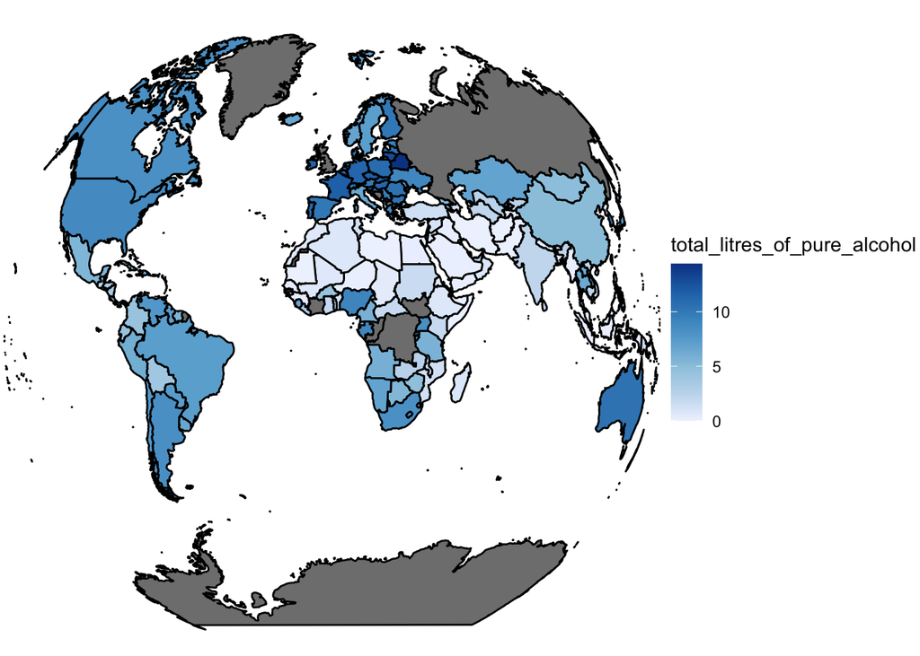

```r
world_df <- ggplot2::map_data("world")

world_full <- left_join(world_df, alcohol_df, by = c("region" = "country"))

ggplot(data = world_full, aes(x = long, y = lat, group = group)) +
  geom_polygon(colour = "black", aes(fill = total_litres_of_pure_alcohol)) +
  coord_map(projection = "gilbert", xlim=c(-180,180)) +
  theme_void() +
  scale_fill_distiller(type = "seq", direction = 1)
```

# Question 2: Give an example of a question of interest about the alcohol data where you would want to construct a visualization other than a map to answer the question. What type of visualization would you construct instead?

An example would be if we were asking “what is the trend of total_litres_of_pure_alcohol in European countries over time?” If we had the data over many years, we could instead use a faceted scatterplot with each year having its own plot. We could also plot one countries’ data on a scatterplot, and have a grid of six or so countries to compare and see how their total alcohol changes over a time.